# Laboratorio 3 - Descripcion de Variables

Luis Pedro Lira 23669, Mario Rocha 23501, Juan Francisco Martinez 23617

2026-03-12

## 1) Carga del dataset y validacion basica

```
## [1] 171748     80
```

**Analisis:** el archivo `listings.RData` carga correctamente y contiene el objeto `listings`, que se usara como `datos`. El dataset tiene un tamano grande (171,748 filas y 80 columnas), por lo que hay suficiente informacion para construir modelos robustos, pero tambien aumenta la probabilidad de encontrar ruido, datos faltantes y formatos inconsistentes.

## 2) Inventario y descripcion general de variables

Variables con mayor porcentaje de faltantes

| variable | tipo | faltantes_n | faltantes_pct | unicos_n |
| --- | --- | --- | --- | --- |
| calendar_updated | logical | 171748 | 100.00 | 0 |
| estimated_revenue_l365d | integer | 95502 | 55.61 | 9746 |
| price | character | 89381 | 52.04 | 2321 |
| neighbourhood_group_cleansed | character | 50683 | 29.51 | 17 |
| review_scores_checkin | numeric | 40324 | 23.48 | 152 |
| review_scores_location | numeric | 40328 | 23.48 | 184 |
| review_scores_value | numeric | 40328 | 23.48 | 187 |
| review_scores_accuracy | numeric | 40312 | 23.47 | 171 |
| review_scores_cleanliness | numeric | 40302 | 23.47 | 195 |
| review_scores_communication | numeric | 40308 | 23.47 | 161 |
| review_scores_rating | numeric | 40287 | 23.46 | 176 |
| reviews_per_month | numeric | 40287 | 23.46 | 1236 |
| beds | integer | 31686 | 18.45 | 40 |
| bathrooms | numeric | 31396 | 18.28 | 38 |
| license | character | 10533 | 6.13 | 52058 |
| bedrooms | integer | 10473 | 6.10 | 23 |
| host_listings_count | integer | 876 | 0.51 | 394 |
| host_total_listings_count | integer | 876 | 0.51 | 481 |
| maximum_maximum_nights | integer | 71 | 0.04 | 396 |
| maximum_minimum_nights | integer | 71 | 0.04 | 211 |
| minimum_maximum_nights | integer | 71 | 0.04 | 383 |
| minimum_minimum_nights | integer | 71 | 0.04 | 185 |
| accommodates | integer | 0 | 0.00 | 16 |
| amenities | character | 0 | 0.00 | 149888 |
| availability_30 | integer | 0 | 0.00 | 31 |

**Analisis:** se observa mezcla de variables numericas, enteras, logicas y de texto. Existen variables practicamente inutiles en su forma actual, por ejemplo `calendar_updated` (100% faltante). Tambien hay campos con faltantes altos (`estimated_revenue_l365d`, `price`, y varias `review_scores_*`), lo que sugiere que cualquier analisis posterior necesitara estrategia de imputacion, descarte o uso selectivo.

## 3) Calidad de datos: faltantes y cardinalidad

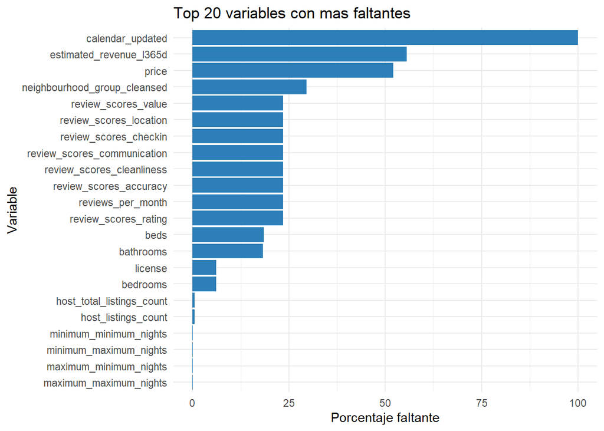

Variables categoricas/texto de alta cardinalidad

| variable | tipo | faltantes_n | faltantes_pct | unicos_n |
| --- | --- | --- | --- | --- |
| listing_url | character | 0 | 0.00 | 171748 |
| picture_url | character | 0 | 0.00 | 167625 |
| name | character | 0 | 0.00 | 163402 |
| amenities | character | 0 | 0.00 | 149888 |
| description | character | 0 | 0.00 | 142952 |
| host_url | character | 0 | 0.00 | 78818 |
| host_picture_url | character | 0 | 0.00 | 76221 |
| host_thumbnail_url | character | 0 | 0.00 | 76194 |
| neighborhood_overview | character | 0 | 0.00 | 61258 |
| license | character | 10533 | 6.13 | 52058 |
| host_about | character | 1 | 0.00 | 41618 |
| host_name | character | 0 | 0.00 | 22307 |
| host_since | character | 0 | 0.00 | 5975 |
| first_review | character | 0 | 0.00 | 5266 |
| last_review | character | 0 | 0.00 | 3904 |

**Analisis:** hay dos hallazgos importantes. Primero, faltantes concentrados en variables de negocio clave (precio, revenue y resenas), lo cual afecta la modelacion del precio. Segundo, muchas columnas de texto tienen cardinalidad extrema (`listing_url`, `name`, `amenities`, etc.); estas variables no conviene tratarlas como categoricas simples, sino mediante tecnicas de texto o extraccion de caracteristicas.

## 4) Descripcion de variables numericas (resumen estadistico)

Resumen de variables numericas (primeras 15)

| variable | min | q1 | mediana | media | q3 | max | faltantes_pct |
| --- | --- | --- | --- | --- | --- | --- | --- |
| id | 6.000000e+00 | 3.599300e+07 | 7.249557e+17 | 6.362915e+17 | 1.182638e+18 | 1.567804e+18 | 0.00 |
| scrape_id | 2.025092e+13 | 2.025092e+13 | 2.025120e+13 | 2.025107e+13 | 2.025120e+13 | 2.025120e+13 | 0.00 |
| host_id | 2.300000e+01 | 2.633063e+07 | 1.080585e+08 | 2.002571e+08 | 3.765745e+08 | 7.320923e+08 | 0.00 |
| host_listings_count | 0.000000e+00 | 1.000000e+00 | 4.000000e+00 | 1.906934e+02 | 3.000000e+01 | 5.531000e+03 | 0.51 |
| host_total_listings_count | 0.000000e+00 | 2.000000e+00 | 6.000000e+00 | 2.745614e+02 | 4.300000e+01 | 1.005000e+04 | 0.51 |
| latitude | 1.898965e+01 | 3.038109e+01 | 3.408984e+01 | 3.377632e+01 | 4.070246e+01 | 4.239184e+01 | 0.00 |
| longitude | -1.597165e+02 | -1.185911e+02 | -1.178653e+02 | -1.094895e+02 | -7.399715e+01 | -7.099600e+01 | 0.00 |
| accommodates | 1.000000e+00 | 2.000000e+00 | 4.000000e+00 | 4.106796e+00 | 6.000000e+00 | 1.600000e+01 | 0.00 |
| bathrooms | 0.000000e+00 | 1.000000e+00 | 1.000000e+00 | 1.551795e+00 | 2.000000e+00 | 3.250000e+01 | 18.28 |
| bedrooms | 0.000000e+00 | 1.000000e+00 | 1.000000e+00 | 1.718121e+00 | 2.000000e+00 | 5.700000e+01 | 6.10 |
| beds | 0.000000e+00 | 1.000000e+00 | 2.000000e+00 | 2.344962e+00 | 3.000000e+00 | 1.320000e+02 | 18.45 |
| minimum_nights | 1.000000e+00 | 2.000000e+00 | 4.000000e+00 | 1.699656e+01 | 3.000000e+01 | 1.125000e+03 | 0.00 |
| maximum_nights | 1.000000e+00 | 9.000000e+01 | 3.650000e+02 | 1.298827e+04 | 1.125000e+03 | 2.147484e+09 | 0.00 |
| minimum_minimum_nights | 0.000000e+00 | 2.000000e+00 | 3.000000e+00 | 1.653510e+01 | 3.000000e+01 | 1.125000e+03 | 0.04 |
| maximum_minimum_nights | 1.000000e+00 | 2.000000e+00 | 7.000000e+00 | 2.353231e+01 | 3.000000e+01 | 1.125000e+03 | 0.04 |

**Analisis:** las variables numericas muestran dispersion alta y posibles outliers fuertes (por ejemplo en conteos y noches maximas). Esto indica que en pasos posteriores sera util considerar transformaciones (logaritmicas o winsorizacion) para evitar que valores extremos dominen los modelos.

## 5) Descripcion de variables categoricas clave

Distribucion de room_type

| room_type | frecuencia |
| --- | --- |
| Entire home/apt | 127649 |
| Private room | 41498 |
| Hotel room | 1764 |
| Shared room | 837 |

Top 10 property_type

| property_type | frecuencia |
| --- | --- |
| Entire rental unit | 50810 |
| Entire home | 32898 |
| Entire condo | 23899 |
| Private room in rental unit | 15265 |
| Private room in home | 13362 |
| Room in hotel | 6276 |
| Entire guesthouse | 4773 |
| Entire guest suite | 3633 |
| Entire townhouse | 3004 |
| Private room in townhouse | 1963 |

Top 10 city

| city | frecuencia |
| --- | --- |
| Los Angeles, California | 45585 |
| New York, New York | 36261 |
| Hawaii | 33457 |
| San Diego, California | 13162 |
| Austin, Texas | 10533 |
| Chicago, Illinois | 8660 |
| San Francisco, California | 7535 |
| Washington, D.C. | 6374 |
| Rhode Island | 5762 |
| Boston, Massachusetts | 4419 |

**Analisis:** la variable `room_type` esta fuertemente concentrada en `Entire home/apt`, seguida por `Private room`, lo cual sugiere segmentacion de mercado clara. En `property_type` y `city` tambien hay concentracion en pocos niveles; esto es util para modelar porque permite crear variables de agrupacion con poder explicativo real sobre el precio.

## 6) Revision de fechas, precio y texto libre

Rango y faltantes de variables de fecha

| variable | min | max | faltantes_pct |
| --- | --- | --- | --- |
| host_since | 2008-03-03 | 2025-12-02 | 0.51 |
| first_review | 2008-06-22 | 2025-12-07 | 23.46 |
| last_review | 2011-03-21 | 2025-12-09 | 23.46 |
| last_scraped | 2025-09-16 | 2025-12-11 | 0.00 |
| calendar_last_scraped | 2025-09-16 | 2025-12-11 | 0.00 |

```
##    Min. 1st Qu.  Median    Mean 3rd Qu.    Max.    NA's
##     8.0   120.0   193.0   750.5   326.0 50123.0   95502
```

```
##   90%   95%   99%
##   629  1034 20000
```

**Analisis:** las fechas cubren desde 2008 hasta finales de 2025, lo cual permite extraer variables temporales utiles (antiguedad del host, recencia de resenas). En `price` hay problemas de calidad: aunque es clave para prediccion, viene como texto y con alto faltante. Al convertirla a numerica aparecen NA adicionales por cadenas vacias, por lo que su limpieza sera una etapa critica del preprocesamiento.

## 7) Conclusiones de la descripcion de variables

1. El dataset es suficientemente grande y diverso para modelar precio, pero requiere limpieza fuerte.
2. Las variables con faltantes muy altos (`calendar_updated`, parte de `review_scores_*`, `estimated_revenue_l365d`, `price`) deben tratarse con criterio estadistico y de negocio.
3. Existen grupos de variables con potencial predictivo alto:
   - Ubicacion: `city`, `neighbourhood_cleansed`, `latitude`, `longitude`.
   - Capacidad y tipo de propiedad: `room_type`, `property_type`, `accommodates`, `bathrooms`, `bedrooms`, `beds`.
   - Reputacion y demanda: `number_of_reviews`, `review_scores_*`, `instant_bookable`.
4. Variables de texto libre tienen informacion rica pero no se deben usar directamente sin transformacion.
5. El siguiente paso natural es definir estrategia de preprocesamiento y particion entrenamiento/prueba para iniciar modelado reproducible.

## 8) Análisis Exploratorio de Datos (EDA)

### 8.1) Distribución de la variable respuesta: price (cruda)

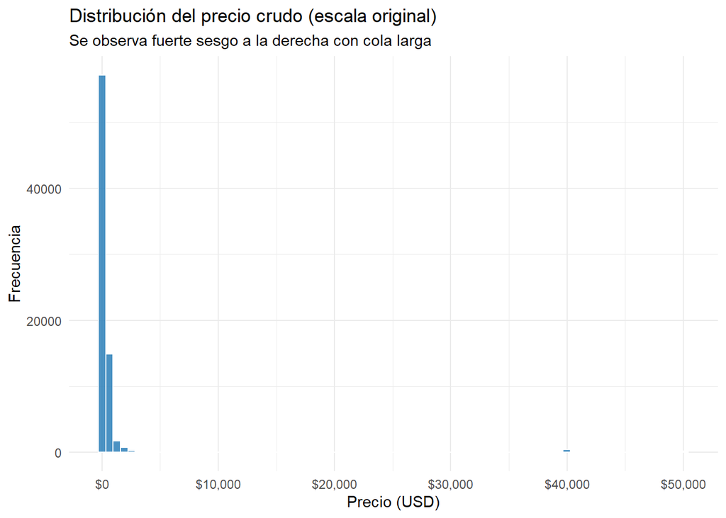

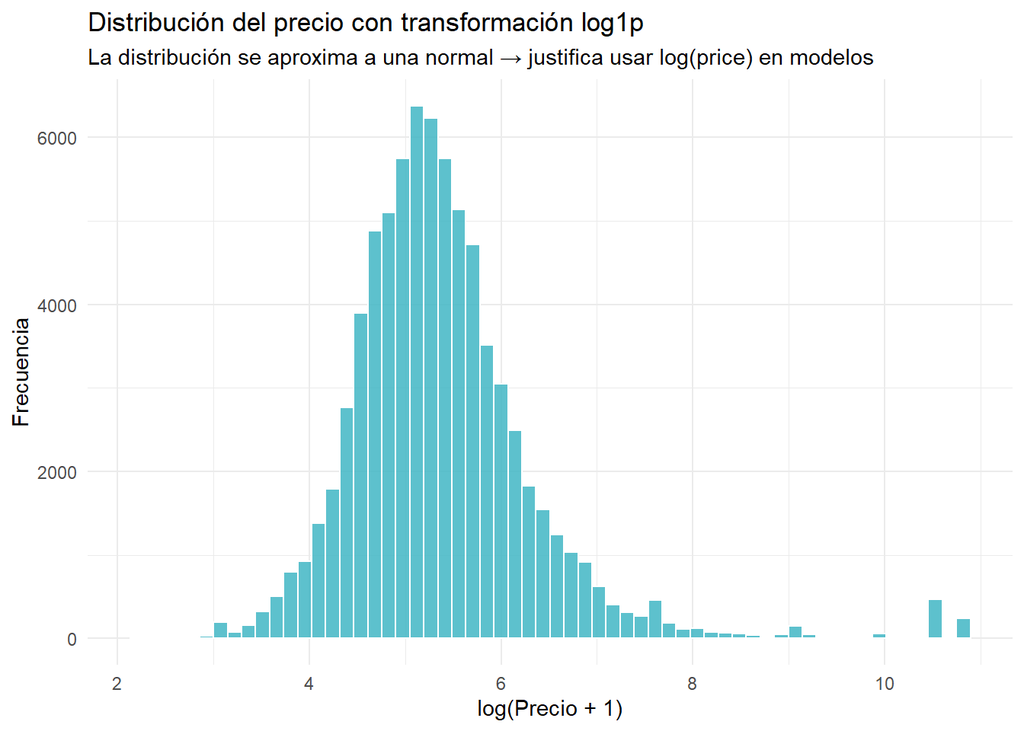

**Análisis:** el precio en su escala original presenta un sesgo positivo (right-skewed) muy marcado, con una cola larga de propiedades de lujo con precios extremos. Al aplicar la transformación `log1p`, la distribución se aproxima a una forma aproximadamente normal, lo que es una condición deseable para modelos de regresión lineal. Esto justifica trabajar con `log(price)` como variable respuesta en la etapa de modelado.

### 8.2) Distribuciones de variables numéricas clave

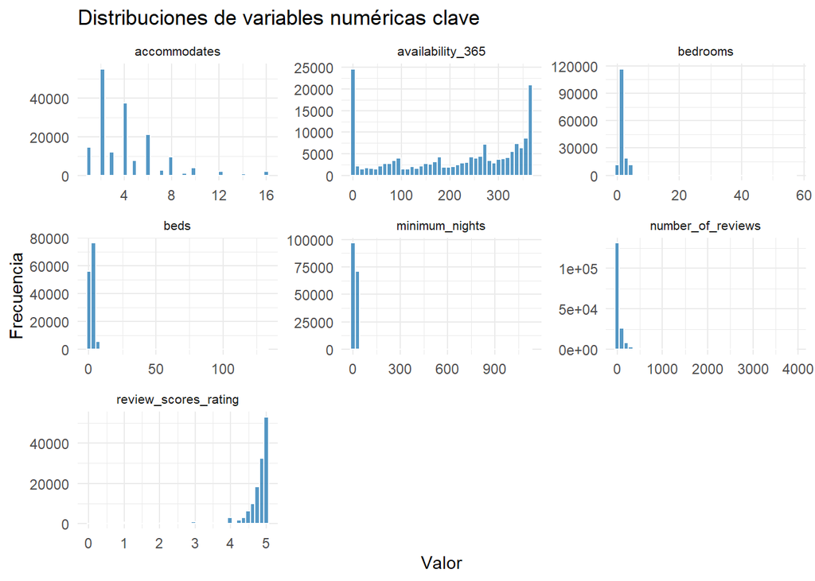

### 8.3) Análisis de outliers en variables numéricas clave

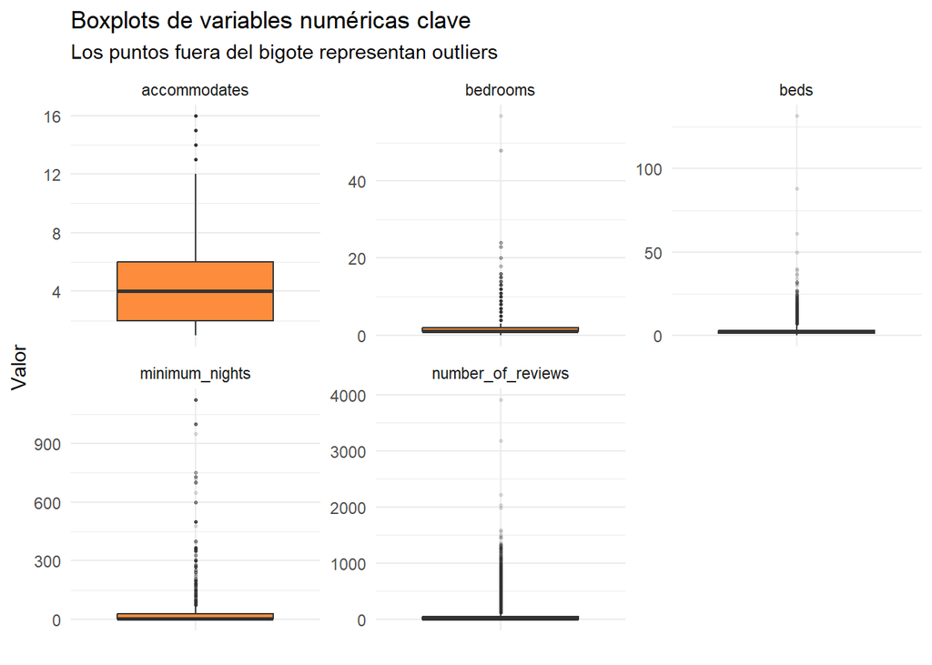

**Análisis:** los boxplots confirman la presencia de outliers severos en varias variables. `minimum_nights` tiene casos extremos (más de 1000 noches mínimas, lo que puede ser un error de entrada o un listing mal configurado). `number_of_reviews` también tiene outliers altos que representan propiedades con historial muy largo. Estos valores deben tratarse con winsorizacion o filtrado antes del modelado para evitar que distorsionen los coeficientes.

### 8.4) Frecuencia de variables categóricas clave

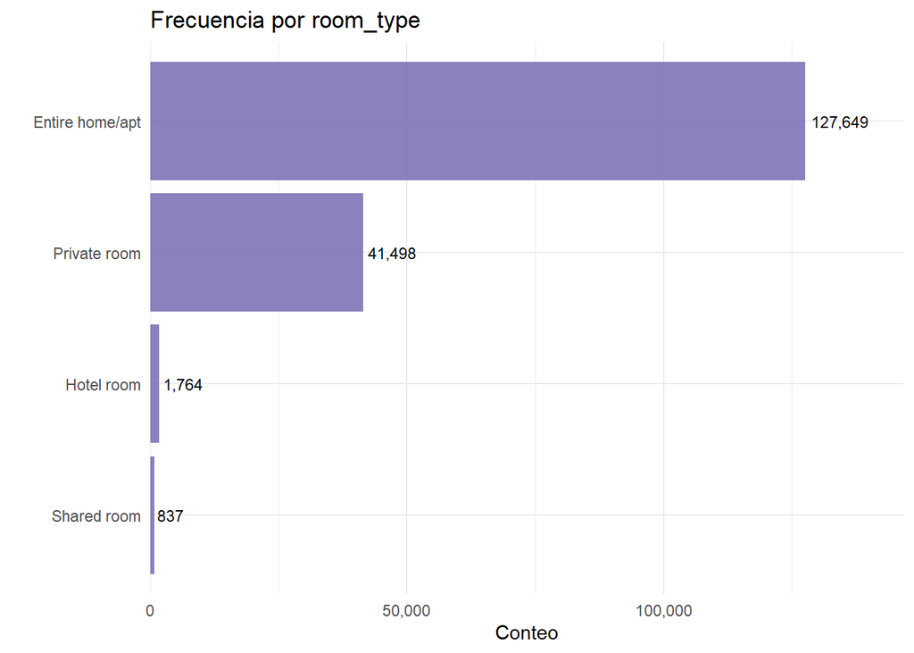

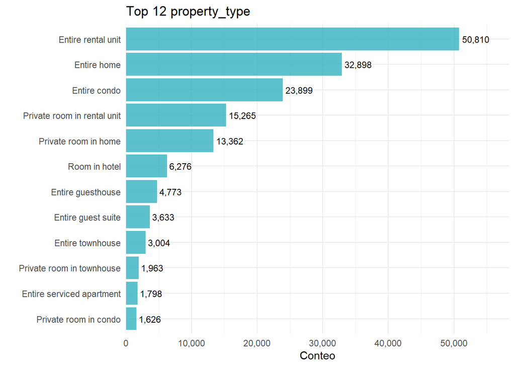

### 8.5) Relación entre accommodates y precio (scatter + tendencia)

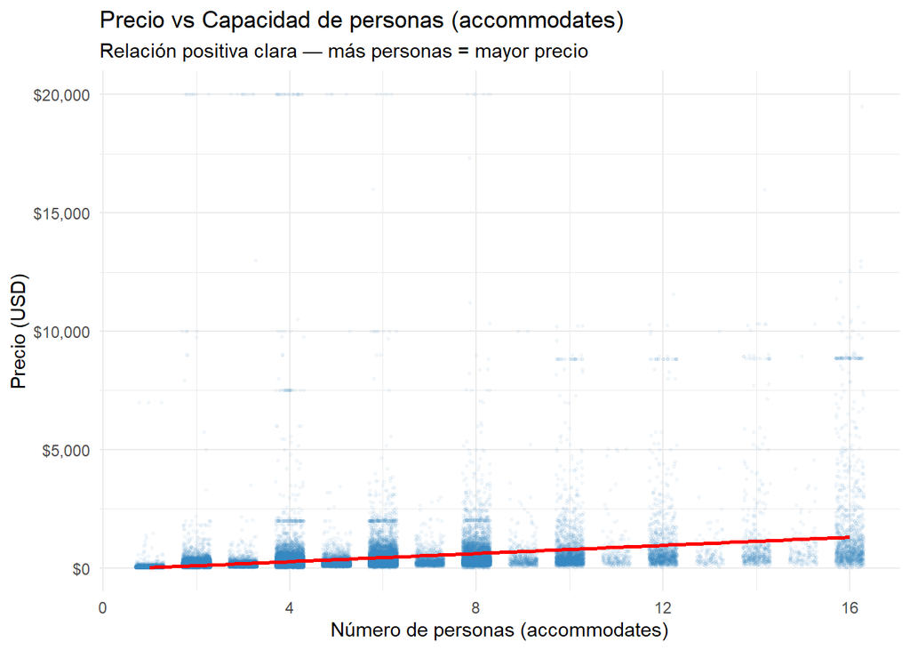

**Análisis:** la relación entre `accommodates` y `price_num` es positiva y consistente: a mayor capacidad, mayor precio. La línea de regresión confirma una tendencia lineal robusta. La dispersión aumenta para valores altos de `accommodates`, lo que sugiere que propiedades grandes tienen mayor variabilidad de precio (influenciada por factores como lujo, ubicación y amenidades). Esta variable es candidata fuerte para los modelos.

### 8.6) Precio mediano por room_type y property_type

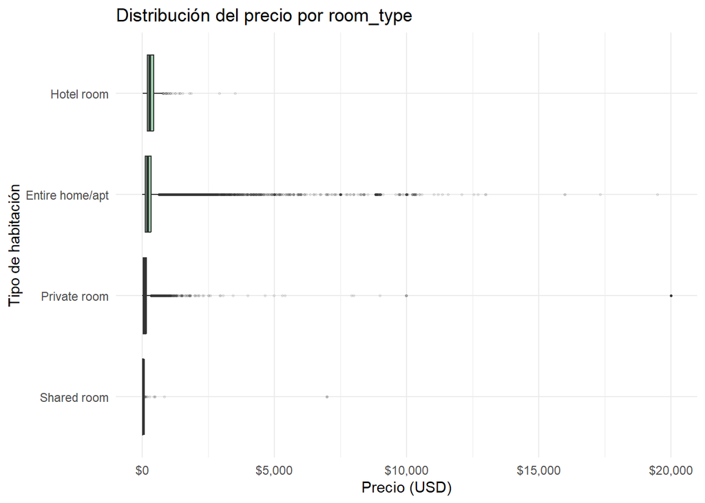

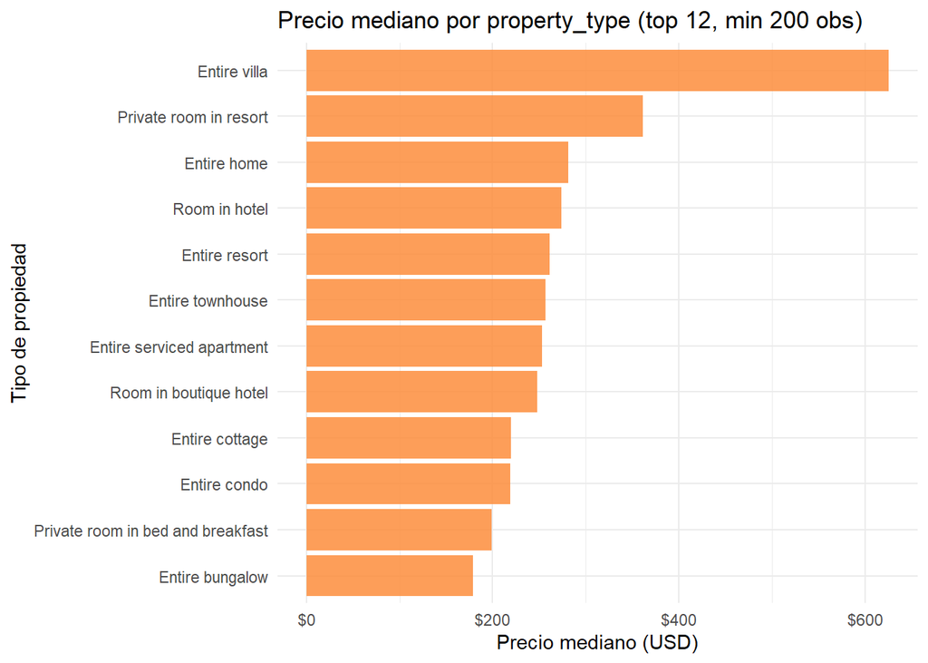

### 8.7) Matriz de correlación visual entre variables numéricas

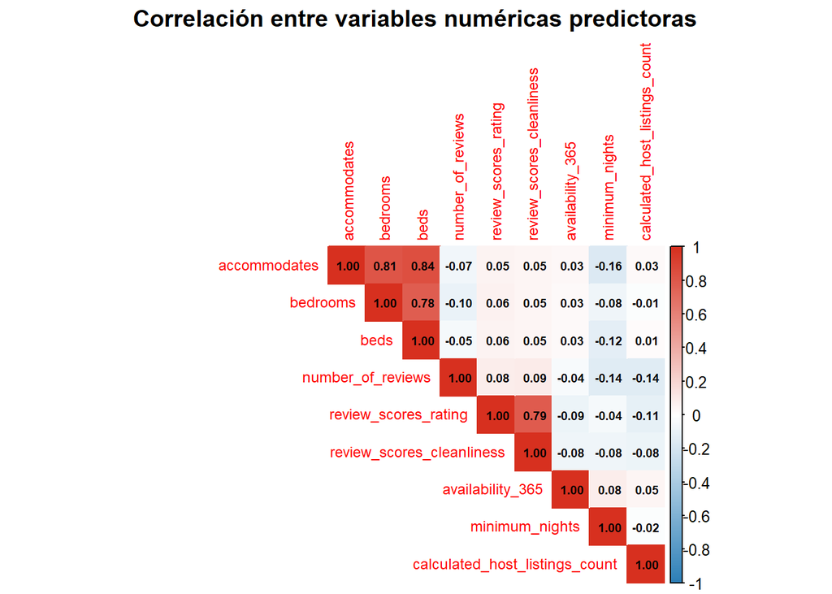

### 8.8) Conclusiones del EDA

1. **`price` requiere transformación logarítmica** antes del modelado: su distribución original es fuertemente sesgada a la derecha y `log1p(price)` se aproxima a una normal.
2. **Las variables de capacidad** (`accommodates`, `bedrooms`, `beds`) son las mejores predictoras numéricas del precio, con relación positiva clara, pero presentan alta colinealidad entre sí.
3. **`room_type` y `property_type`** son predictores categóricos de alto valor explicativo. Deben incluirse como dummies o factores en los modelos.
4. **Outliers significativos** en `minimum_nights` y `number_of_reviews` requieren filtrado o winsorizacion antes del modelado.
5. **`review_scores_rating` y `number_of_reviews`** tienen poca correlación con el precio, lo que sugiere que la popularidad o calidad percibida no determina el precio cobrado.
6. El EDA valida y extiende las conclusiones de la sección 7: las variables de ubicación, capacidad y tipo de propiedad deben ser el núcleo del modelo predictivo.

## 9) Limpieza de la variable respuesta: price

```
## Filas despues de limpiar price: 75531
```

```
## Rango de price_num: 8 - 20000
```

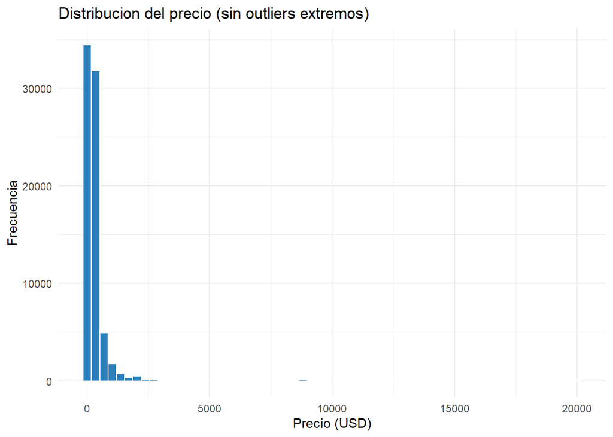

**Analisis:** se eliminaron registros con precio nulo, cero o por encima del percentil 99 para reducir el efecto de outliers extremos que distorsionarian los modelos. La distribucion resultante muestra sesgo a la derecha tipico en precios de alquiler: la mayoria de propiedades se concentra en rangos bajos, con una cola larga hacia precios altos. Esto sugiere que una transformacion logaritmica podria ser util en el modelado.

## 10) Relacion entre variables numericas y el precio

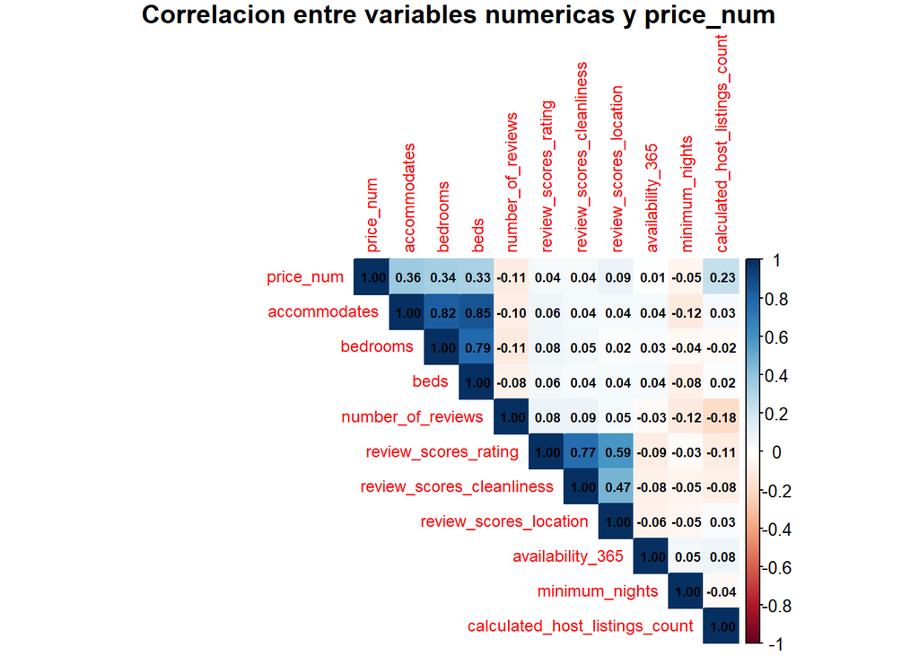

**Analisis:** las variables con mayor correlacion positiva con el precio son `accommodates`, `bedrooms` y `beds`, lo cual tiene sentido: propiedades mas grandes y con mayor capacidad tienden a costar mas. Las variables de reviews muestran correlaciones debiles con el precio, lo que indica que la calificacion percibida no necesariamente se refleja en el precio cobrado. `availability_365` y `minimum_nights` tienen correlaciones muy bajas, sugiriendo que son menos utiles como predictores directos del precio.

## 11) Precio segun tipo de habitacion (room_type)

Precio mediano y medio por room_type

| room_type | n | mediana_precio | media_precio |
| --- | --- | --- | --- |
| Hotel room | 290 | 278 | 394.46 |
| Entire home/apt | 65479 | 204 | 358.30 |
| Private room | 9547 | 85 | 280.00 |
| Shared room | 215 | 42 | 149.37 |

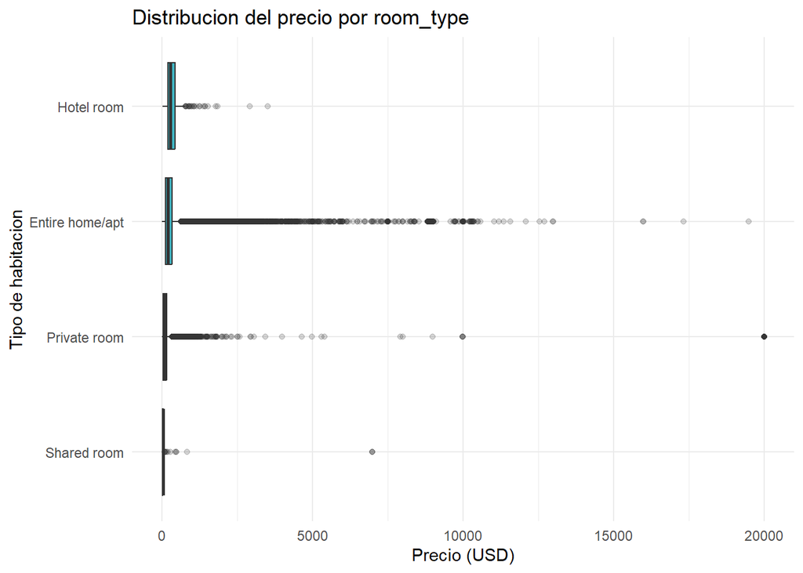

## 12) Precio segun numero de personas que puede alojar (accommodates)

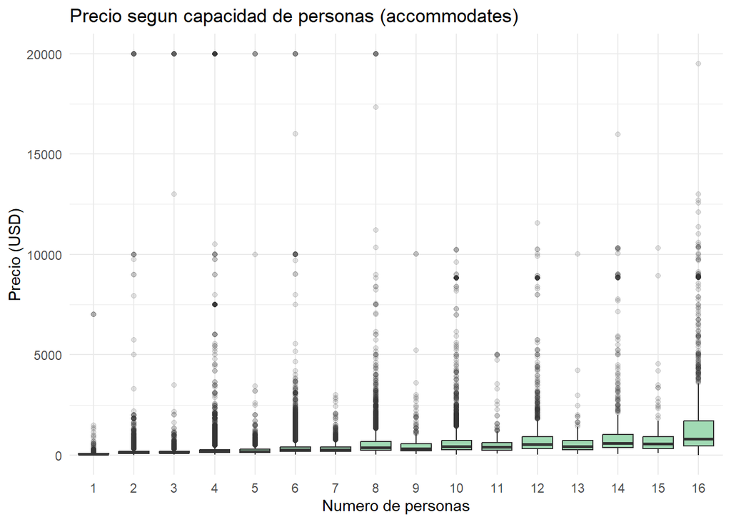

## 13) Precio segun ciudad

| city | n | mediana_precio |
| --- | --- | --- |
| Rhode Island | 4935 | 270 |
| Hawaii | 32757 | 230 |
| Boston, Massachusetts | 3466 | 203 |
| San Diego, California | 11282 | 175 |
| Chicago, Illinois | 7758 | 152 |
| Austin, Texas | 10476 | 135 |
| Washington, D.C. | 4857 | 124 |

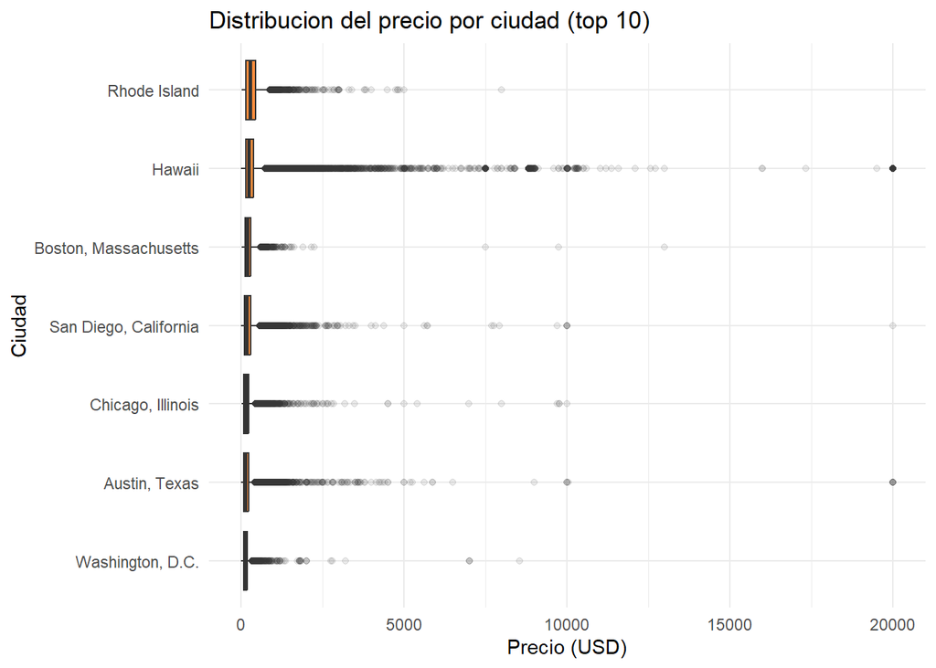

## 14) Precio segun numero de resenas (number_of_reviews)

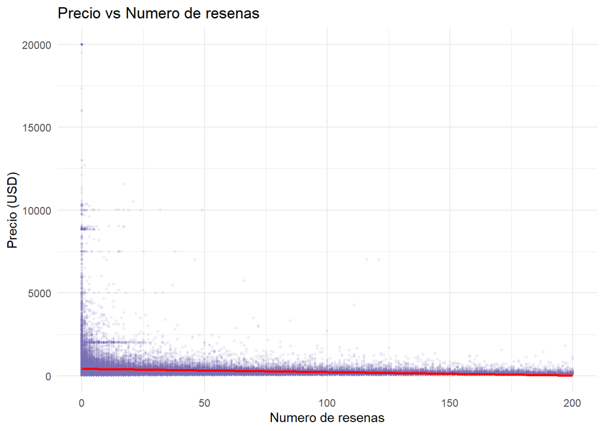

**Analisis:** la relacion entre numero de resenas y precio es debil y ligeramente negativa. Propiedades con muchas resenas no necesariamente son mas caras; de hecho, propiedades mas baratas tienden a tener mas rotacion y por ende mas resenas. Esto sugiere que `number_of_reviews` no sera un predictor fuerte del precio, aunque puede ser util para capturar popularidad de la propiedad.

## 15) Resumen: variables mas relacionadas con el precio

Correlacion de variables numericas con price_num

| variable | correlacion |
| --- | --- |
| accommodates | 0.3602340 |
| bedrooms | 0.3381447 |
| beds | 0.3289944 |
| calculated_host_listings_count | 0.2307018 |
| review_scores_location | 0.0876783 |
| review_scores_cleanliness | 0.0428076 |
| review_scores_rating | 0.0400502 |
| availability_365 | 0.0050883 |
| minimum_nights | -0.0542877 |
| number_of_reviews | -0.1074795 |

**Analisis final:** las variables con mayor relacion lineal con el precio son `accommodates`, `bedrooms` y `beds`. Las variables de reviews tienen correlaciones muy bajas. Adicionalmente, los analisis graficos mostraron que `room_type` y `city` son predictores categoricos importantes. Para los modelos de regresion se priorizaran estas variables, complementadas con transformacion logaritmica del precio para corregir el sesgo en la distribucion.

## 16) Preparacion analitica y dataset final de modelado

Esta seccion formaliza el preprocesamiento para entregar un dataset de modelado reproducible al siguiente integrante.

Decision oficial de respuesta: comparar sesgo en price vs log(price)

| variable | skewness |
| --- | --- |
| price_num | 9.865 |
| log_price | 1.812 |

Particion final reproducible (seed = 23617)

| dataset | filas | proporcion |
| --- | --- | --- |
| train_clean | 60988 | 0.7999 |
| test_clean | 15258 | 0.2001 |

Tratamiento de outliers aplicado con cuantiles de train

| variable | p01_train | p99_train | clips_train | clips_test |
| --- | --- | --- | --- | --- |
| maximum_nights | 7.00 | 1125.000 | 471 | 107 |
| availability_365 | 1.00 | 365.000 | 581 | 143 |
| calculated_host_listings_count | 1.00 | 540.000 | 482 | 105 |
| reviews_per_month | 0.03 | 6.740 | 1078 | 268 |
| host_tenure_years | 0.66 | 15.058 | 1188 | 325 |

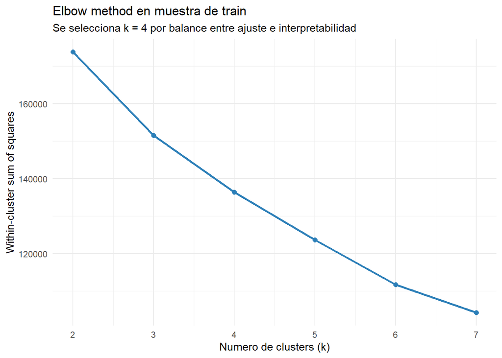

Perfil de grupos y efecto esperado sobre precio

| segment_id | n | pct_total | precio_geometrico | accommodates_prom | bedrooms_prom | bathrooms_prom | review_rating_prom | availability_prom | interpretacion |
| --- | --- | --- | --- | --- | --- | --- | --- | --- | --- |
| 4 | 11121 | 14.59 | 548.15 | 10.21 | 4.10 | 3.19 | 4.86 | 238.3 | Segmento premium: alta capacidad y mayor precio esperado. |
| 3 | 22206 | 29.12 | 244.91 | 4.36 | 1.44 | 1.40 | 4.78 | 227.4 | Segmento medio-alto: unidades completas con precio intermedio. |
| 1 | 29117 | 38.19 | 174.36 | 3.94 | 1.39 | 1.32 | 4.84 | 221.7 | Segmento economico: menor precio y menor capacidad relativa. |
| 2 | 13802 | 18.10 | 135.17 | 3.19 | 1.44 | 1.32 | 4.80 | 250.5 | Segmento economico: menor precio y menor capacidad relativa. |

Datasets finales limpios listos para modelado

| dataset | filas | columnas | n_na |
| --- | --- | --- | --- |
| train_clean | 60988 | 27 | 0 |
| test_clean | 15258 | 27 | 0 |

Set final de variables candidatas

| predictor |
| --- |
| city |
| room_type |
| property_type_group |
| neighbourhood_group |
| host_is_superhost |
| host_identity_verified |
| instant_bookable |
| accommodates |
| bathrooms_num |
| bedrooms |
| beds |
| minimum_nights_log1p |
| maximum_nights |
| availability_365 |
| number_of_reviews_log1p |
| reviews_per_month |
| review_scores_rating |
| host_tenure_years |
| host_response_rate_num |
| host_acceptance_rate_num |
| calculated_host_listings_count |
| latitude |
| longitude |
| review_missing_flag |
| response_missing_flag |
| segment_id |

Variables descartadas y justificacion

| variable | razon |
| --- | --- |
| id | Identificador unico, no predictivo. |
| listing_url | URL unica (alta cardinalidad, irrelevante para precio). |
| scrape_id | Metadato tecnico del scraping. |
| last_scraped | Fecha de scraping, no representa valor intrinseco del listing. |
| name | Texto libre de alta cardinalidad. |
| description | Texto libre sin vectorizacion en esta fase. |
| neighborhood_overview | Texto libre sin vectorizacion en esta fase. |
| host_about | Texto libre sin vectorizacion en esta fase. |
| amenities | Texto semi-estructurado de muy alta cardinalidad (se reserva para NLP). |
| calendar_updated | 100% faltante. |
| estimated_revenue_l365d | Variable con 55%+ faltantes y potencial fuga temporal. |
| license | Cobertura incompleta y reglas heterogeneas por ciudad. |

**Explicacion ejecutiva del preprocesamiento (Parte 1):** 1. `price` se limpio de simbolos y comas; se eliminaron precios no validos (`NA` o `<= 0`). 2. La respuesta oficial es `log_price` porque reduce el sesgo de cola larga y estabiliza varianza. 3. Se uso split `80/20` estratificado por `city x room_type` con `seed = 23617` para mantener representatividad geografica y de tipo de alojamiento. 4. Faltantes numericos se imputaron con mediana de train; categoricos se imputaron como `Unknown`. 5. Categorias raras se agruparon en `Other` con umbral minimo de frecuencia para evitar niveles inestables. 6. Outliers en predictores sesgados se winsorizaron al rango `p01-p99` aprendido en train. 7. Se hizo clustering k-means (`k = 4`) para segmentar listings y agregar `segment_id` como variable explicativa adicional. 8. Se generaron y guardaron los entregables de Parte 2: `train_clean`, `test_clean`, `response_var`, `predictor_set`.

### LINK DE GITHUB

https://github.com/Cisco890/Lab3_DM.git